[figure not shown]

# Planning under uncertainty

AI-guided design of efficient clinical trials with BATON

Naim Rashid, PhD

Associate Professor, Department of Biostatistics, Gillings School of Global Public Health  
Member, Lineberger Comprehensive Cancer Center · UNC Chapel Hill

NextGen TriBix Symposium · November 17, 2026

Section 1

1The stakes

How much of a drug’s fate is set in its earliest trials?

2The design problem

3BATON

4BATON in practice

5Looking to the future

## Drug development usually follows three phases before approval

Phase I

First trials in people. Is it safe, and at what dose?

3 to 12 months

typical gap in oncology

Phase II

Is there a sign that it works?

17 months

average gap, where a Phase II–III gap exists

Phase III

Often the pivotal trial. Is there convincing evidence of benefit?

→

Approval

Fewer candidates continue. Schematic.17 months: Tufts CSDD · non-expedited approvals, 2008 to 2018 (Getz 2021)

Phases can overlap or be combined.

## Developing one new therapy is slow and expensive

10.5 years  
from Phase I to approval, based on successful transitions

$1.1 billion  
median cost per approved drug, failed candidates included (2018 dollars)

Each year of development is a year patients wait.

BIO, Informa, QLS Advisors 2021 · Wouters, McKee, Luyten, JAMA 2020, corrected 2022

## Many problems become apparent only in late-stage trials

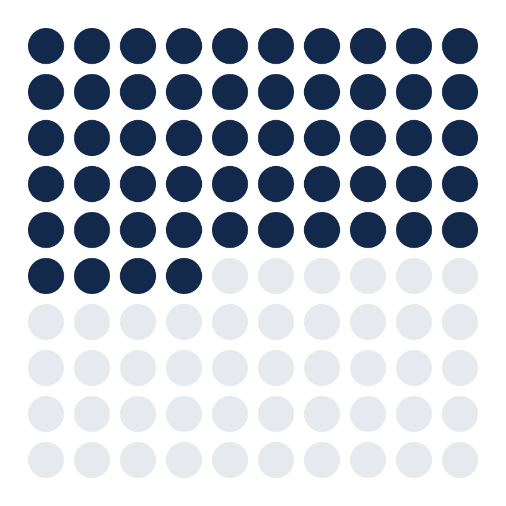

54%  
failed in late-stage development  
640 therapeutics that entered  
pivotal trials in 1998–2008 Most often the drug did not show enough benefit (57% of failures). Hwang et al., JAMA Internal Medicine 2016

What can we do in the early trials to make a late failure less likely?

Late failures have many causes. Earlier-phase trials can also affect later-phase trials in ways that are hard to predict.

## How best to design early trials for later success is not yet clear

More patients at 960 mg cannot show how 240 mg compares.

1Different measures

Early trial (small)

reads out

A short-term signal

tumor shrinkage, side effects

Does one predict the other?

Later trial (large)

reads out

A long-term outcome

survival

2Separate designs

Each phase has its own targets.

3Too many combinations

How many patients in each phase, and what result moves a treatment forward.

More patients later may not answer what the early trial never asked.

## Early decisions become downstream commitments

Sotorasib · KRAS G12C lung cancer

Phase I

960 mgHighest tested

→

Accelerated approval

960 mg

→

Postapproval comparison

960 mgvs240 mgFDA-required

| Phase II results | 960 mg | 240 mg |
| --- | --- | --- |
| Progression-free survival | 5.4 months | 5.6 months |
| Severe side effects (grade 3+) | 35.6% | 19.2% |
| Tumor response | 32.7% | 24.8% |

Descriptive comparison[Trial](https://pubmed.ncbi.nlm.nih.gov/39029295/) · [FDA](https://www.fda.gov/media/172698/download)

The highest dose patients tolerate, or the lowest dose with full benefit?

## Better early trials are possible. Designing them is the hard part.

So far

10.5 years

from Phase I to approval

54%

of late-stage candidates failed

960 mg

chosen early, compared with 240 mg only after approval

Each phase can use a more efficient design, one that adapts as the data arrive.

The hard part is finding a design that is efficient and still meets the evidence requirements. That search is our focus today. We return to the dose question at the end.

Section 2

1The stakes

2The design problem

Start with one Phase II decision. Is there enough evidence to continue?

3BATON

4BATON in practice

5Looking to the future

## A clinical trial is an experiment built for a decision

The question

Does the treatment beat a benchmark or a control?

How patients are used

Everyone gets the treatment, or patients are assigned to treatment or control.

Two errors

Does not work

GO

Works

STOP

Advance a treatment that fails, or drop one that works.

Two choices dominate: how many patients, and what evidence is enough to take the treatment to the next phase.

## An adaptive trial can reach that decision sooner

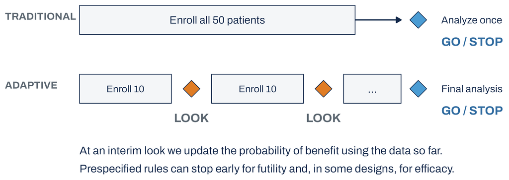

When to look and how much evidence is enough are two choices we must tune. Both change how well the trial performs.

## A good design has to meet four requirements at once

Must meet

1

Rarely advance a treatment that fails

Type I error at most

10%

2

Usually advance one that works

Power at least

80%

Then improve

3

Keep the sample size small

4

Stop early if it fails

Calibration tunes the design until it meets 1 and 2. Among designs that do, we then improve 3 and 4.

## Simulation tests one design in two scenarios

Complex designs usually have no straightforward formula for power or type I error, so we use simulation.

1Fix the design

its settings and decision rules

→

2Assume the truth

treatment effect, enrollment, outcomes

→

3Simulate many trials

count how often the rules say go

Ineffective  
(null)

target: at most 10%

4.2%type I error

2,100 of 50,000 say go

Effective  
(alternative)

target: at least 80%

82%power

41,000 of 50,000 say go

Fixed: settings, rules, model and assumptions. Only the treatment effect changes.Illustrative numbers

One design meets both targets. How do we find a design like that for a real trial?

## ARPA-H asked us to build complex adaptive features into EVOLVE

ADAPT is an ARPA-H program to identify and target changes in metastatic cancers.

[figure not shown]

Current state

ADAPT’s “future state”

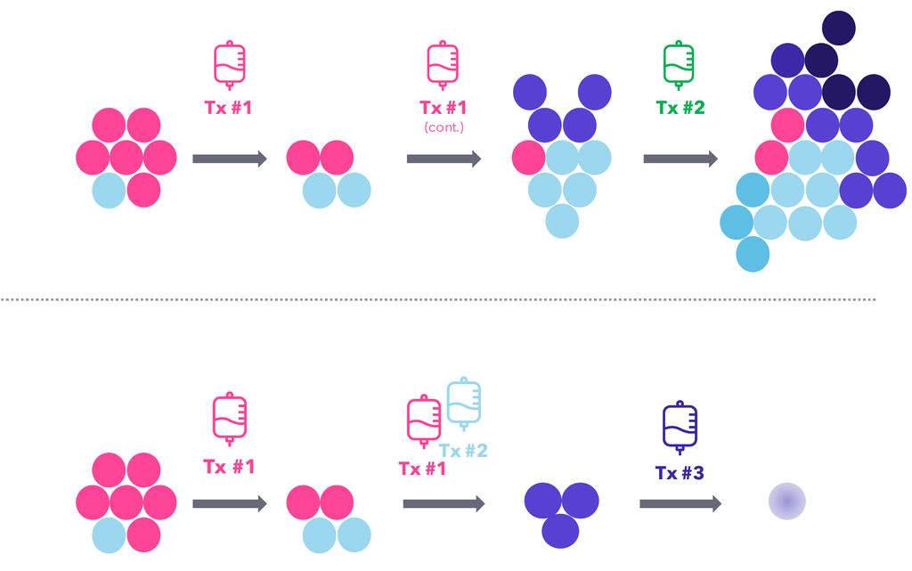

Graphic: ARPA-H ADAPT Proposers’ Day, approved for public release

EVOLVE is the breast cancer platform trial we proposed to ADAPT. Each biomarker-defined group of patients gets its own subtrial.

EVOLVE master protocol

Metastatic breast cancer

Three example subtrial designs

Single-arm

8 settings

Randomized

8 settings

Seamless

13 settings

One protocol hosts 10 to 15 subtrials, and each has eight or more interacting settings to tune.

## I could not verify that a hand-tuned design met the power target

Eight design parameters (settings) in the EVOLVE calibration example

The outcome is progression-free survival, analyzed with a Bayesian piecewise exponential model. Interim reviews can stop the trial if benefit looks unlikely.

Max sample size

Spacing of interim looks

Events needed before a decision

Futility threshold

Efficacy threshold

Margin over the benchmark

Strength of the prior

Resolution of the survival model

Changing one setting can change which values work for the others.

Target power: at least 80%

Several more subtrials were waiting. How could we search so many settings systematically?

## A grid search can produce 100 million candidate designs

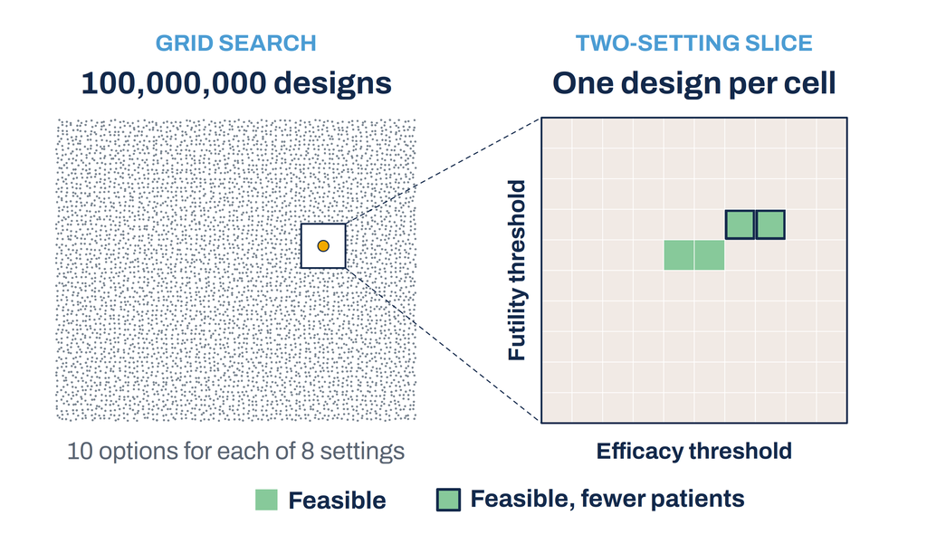

Think hyperparameter tuning for trial rules.  
Is there a smarter way to pick the next design to test?

## Why finding a good design is hard

1

Many settings that interact

Eight or more in each EVOLVE subtrial.

2

No formula

Each candidate design has to be checked by simulation.

3

Too many candidates

A grid over eight settings has 100 million designs.

We need a search that learns which designs are worth simulating.

Section 3

1The stakes

2The design problem

3BATON

How do we search intelligently?

4BATON in practice

5Looking to the future

## Our solution: BATON, Bayesian Adaptive Trial Optimization

BATON applies Bayesian optimization, the machine learning method used to tune model hyperparameters, to trial rules.

You supply

- a trial simulator
- an analysis model
- a performance evaluator
- targets and an objective

Start from a known design or specify your own trial

Space-filling start

Model-guided search

Futility threshold

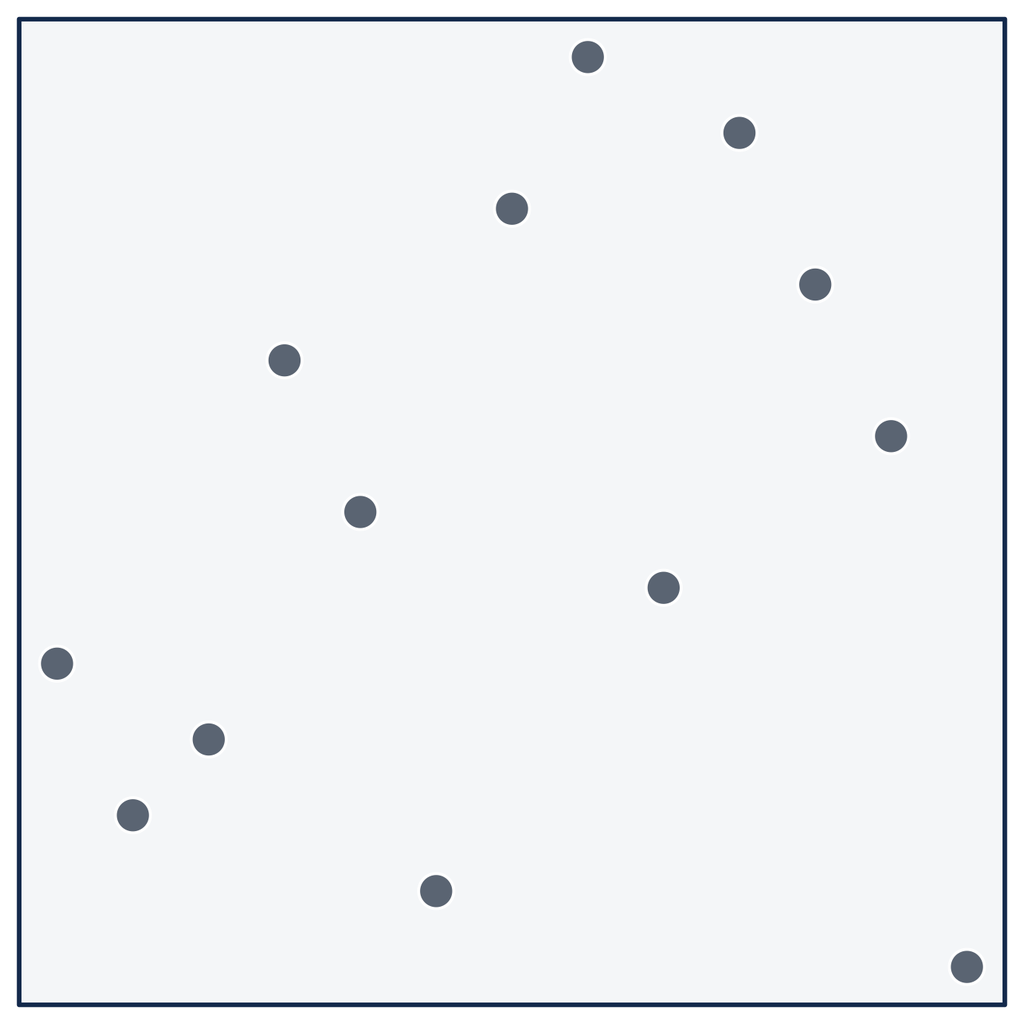

Fit model→

Futility threshold

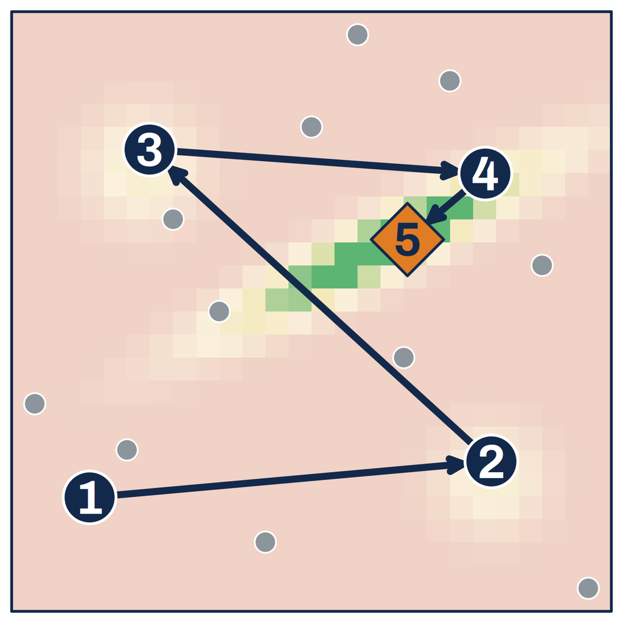

Efficacy threshold

Efficacy threshold

Two settings shown. Each dot is one design tested in many simulated trials. Meets both targetsCandidate to verify

Simulate → Fit → Choose, and repeat. Then check the best design with fresh simulations.

## A nonlinear model predicts how untested designs might behave

X

Design parameters

Y

Simulated outcomes

Initial  
sample

.3.9326

72%3%16.2

.2.8365

88%13%19.5

Guided  
search

.3.8305

77%8%14.6

.3.8325

→

82%8%15.1

Next  
design

.3.8315

Pending

x<sub>1</sub>x<sub>2</sub>x<sub>3</sub>x<sub>4</sub>

PowerType I  
errorExpected  
enrollment

[figure not shown]

Simulate → Fit *Y* from *X* → Choose

Illustrative values

## BATON balances potential improvement with feasibility

Which candidate is worth the next simulation?

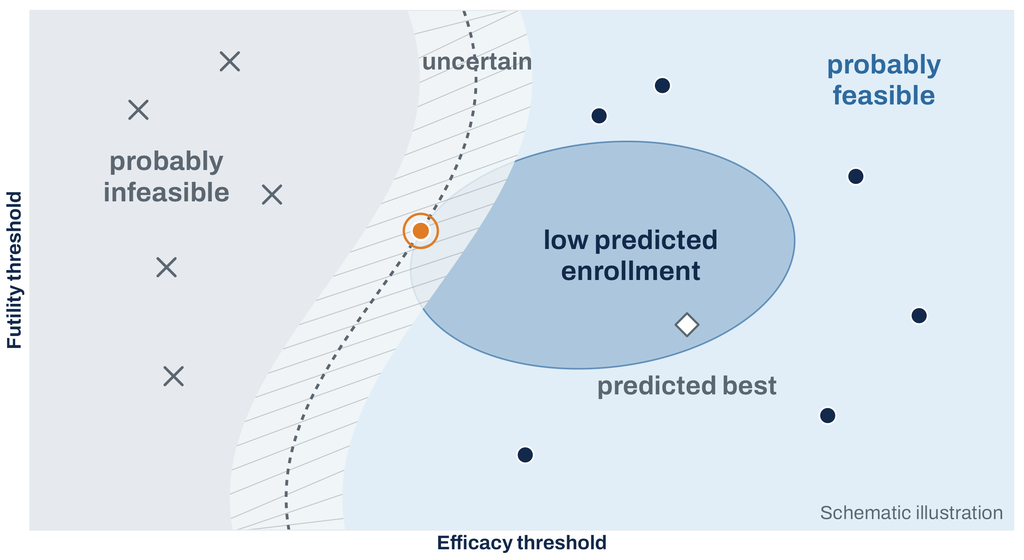

Test the orange point. It could reduce enrollment and still meet both targets.

Simulate it, update the predictions, and choose again.

## Verifying the final design with fresh simulations

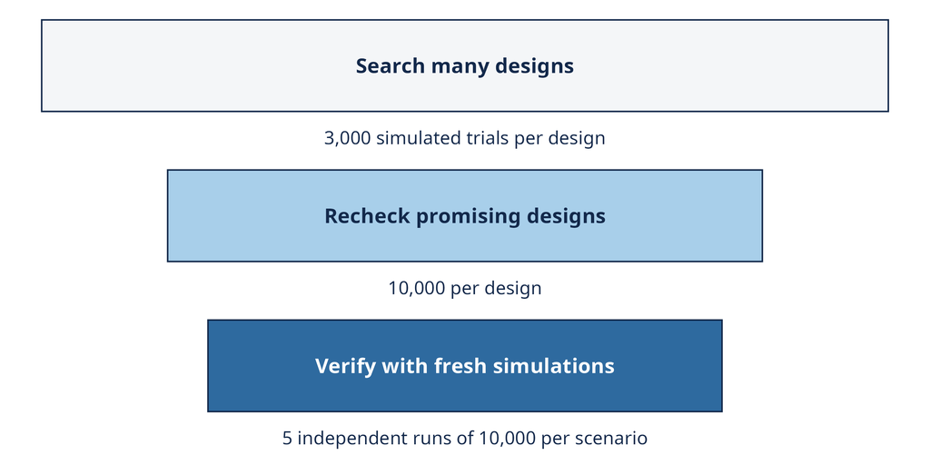

Fresh simulations check both targets before BATON reports a design, because the search can favor designs whose early estimates were lucky.

Section 4

1The stakes

2The design problem

3BATON

4BATON in practice

What did it find for a real trial?

5Looking to the future

## First, check BATON where we know the exact answer

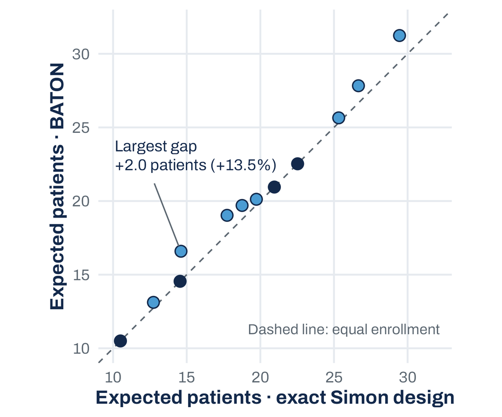

Simon’s two-stage design

Only four settings, so every possible design can be listed and the best is known exactly.

3.6%

above the exact best design, on average

4

exact matches (dark points)

All 12

test problems met both targets

Three ways to define best

Optimal

fewest patients on average

Minimax

smallest maximum

Admissible

a compromise

## BATON found a better EVOLVE design with less computing time

Simon

4 settings. Every design can be listed.

EVOLVE (the breast cancer platform trial)

8 to 13 settings. Listing every design is not possible.

One randomized EVOLVE subtrial, 8 settings. The score blends max sample size and expected enrollment.

Score (lower is better)

Computing

BATON

model-guided search

51.3

76 core-hours

Grid, same effort

2 values per setting, 256 designs

101.3

matched to BATON

Grid, finer

3 values per setting, 6,561 designs

70.5

3,594 core-hours

BATON and the same-effort grid are means of 5 runs (BATON median 76 core-hours per run). The finer grid is one run.

A coarse grid does worse. A finer grid costs about 47 times more and still does worse.  
It is the hyperparameter tuning problem.  
BATON’s design was then confirmed in separate, independent simulations.

## EVOLVE had to settle each subtrial’s max sample size in advance

The team needed a max sample size about three months before first enrollment.

Max sample size needed

about three months

First enrollment

This EVOLVE design has eight settings. We estimated its performance by simulation.

Interim schedule

The calibrated rules fixed when the interim reviews happen.

Capacity across subtrials

The steering committee weighed the max sample size against expected enrollment before choosing a design for the first subtrial.

How large should the max sample size be when an early stop could leave part of it unused?

## Would you plan for up to 86 patients or 103?

EVOLVE’s ER-positive subtrial, doublet against triplet (patients in both arms)

|  | Optimal (fewest patients if ineffective) | Minimax (smallest max sample size) | Admissible (compromise) |
| --- | --- | --- | --- |
| Max sample size | **103** | **86** | **91** |
| Average enrollment if ineffective | **59.2** | **70.8** | **63.9** |
| Power | 80.4% | 81.7% | 81.0% |
| Type I error | 8.2% | 9.4% | 8.6% |

Planning for 17 fewer patients at most means enrolling about 12 more on average if the treatment is ineffective.

Both met the power and type I error targets in simulation.

Admissible is the compromise between them, and it met both targets too.

Each design is the best of 5 searches. Max sample sizes varied across searches (SD about 10 for Optimal, 2 to 4 for the others).

## Change the objective. Keep the evidence targets.

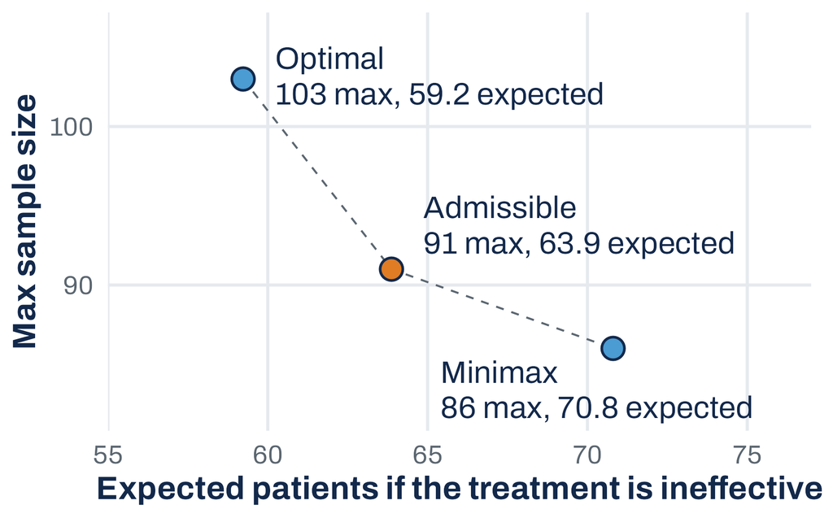

**What can the team prioritize?**

- **Optimal:** Fewest patients on average if the treatment is ineffective
- **Admissible:** Balance average and maximum enrollment
- **Minimax:** Smallest maximum enrollment

Simon defined these for his two-stage design. BATON carries them to the wider family of adaptive trials by swapping in an objective built to mimic each one.

Different priorities give different verified options. For its first subtrial, EVOLVE’s steering committee chose Admissible, inside the three-month window.

## Same search, different trial rules

Randomize patients from the start

**Stage 1**Screen the experimental arm against a historical benchmark.

→

**Decision to proceed**Apply the planned rule.

**No-go or ambiguous**Resolve under Stage 1 rules.

**Go to Stage 2**Compare experimental and reference arms.

[figure not shown]

The seamless design as calibrated, with 13 possible settings

BATON calibrated it, but Stage 2 always stopped at its first look.

## What if the simulator assumes perfect classification?

Work in progress

Keep the trial rules fixed. Vary how often the biomarker test misclassifies patients.

Power lost as the test misclassifies more patients

Same specimen

↓

Different test call

↓

Different subtrial or treatment decision

With 10% misclassified, power fell by about 8 to 11 points. Type I error barely moved.

Simulate plausible error rates in BATON. Recheck power and type I error, then recalibrate.

Separate simulation study, not an EVOLVE result. Adapted from the FDA OSEL talk *When Biomarkers, Assays, and Protocols Co-evolve*.

## A public service announcement on AI-written code

**The help:** AI can write analysis code quickly, including a custom trial simulator for BATON.

**The danger:** The code runs and the results look plausible, yet it can answer a different question than the one you asked.

**The check:** Can you say what the code assumes, and would you defend each assumption?

[figure not shown]

[StatsUpAI companion resources](https://github.com/naimurashid/staying-in-drivers-seat-resources)

If you cannot explain or defend a choice you made with AI’s help, you may be delegating too much.

## You can’t evaluate what you don’t know, and you should never outsource your judgment to an external tool.

Section 5

1The stakes

2The design problem

3BATON

4BATON in practice

5Looking to the future

What changes when one trial shapes what the next can learn?

## What BATON has shown, and what it has not

Shown in EVOLVE · Phase II

Verified designs

checked in fresh simulations

Real choices

max sample size against average enrollment

About 47 times less computing

than a finer grid, on one randomized subtrial

More complex trials

calibration runs on a 13-setting seamless design

Not yet shown

Phase I

Can BATON guide dose finding?

Phases I and II

How do early choices shape Phase III?

The whole program

Less time, fewer patients, lower cost?

The rest of this talk is about the second list.

## Phases are planned one at a time, and the costs add up

**10.5 years**

**from Phase I to approval**

**54%**

**failed in late-stage development**

**Phase I** 20–100

Informs dose choice

→

**Phase II** Up to several hundred

Tests for activity

→

**Phase III** 300–3,000

Tests benefit at that dose

Could we design the phases together, to reach a reliable answer sooner, with fewer patients and lower cost?

[FDA trial sizes](https://www.fda.gov/patients/drug-development-process/step-3-clinical-research) · [Hwang et al. (2016)](https://jamanetwork.com/journals/jamainternalmedicine/fullarticle/2565686) · [FDA case studies (2017)](https://www.fda.gov/about-fda/reports/22-case-studies-where-phase-2-and-phase-3-trials-had-divergent-results)

## The dose chosen in Phase I carries through Phases II and III

Illustrative example

Two doses shrink tumors about equally. The higher dose has more side effects, as with sotorasib.

**A · Tolerability first**Choose the dose by a toxicity limit.The higher dose advances. More patients may cut back or stop.

**B · Activity and tolerability**Compare the doses on both measures.The lower dose advances. It may take more patients early.

To test in simulationFor each way of choosing the dose, how often does Phase III confirm benefit, and with how many patients?

## Reusing earlier patients could save time. How much should count?

PARTNER · A rare trial that counted earlier patients in its final comparison

**Treatment arm** **Stages 1–2Earlier patients** **Stage 3New patients** **Final comparisonOutcomes from both groups**

**Control**Chemotherapy alone

+

→

**Selected schedule**Olaparib 48 hours after chemotherapy

+

→

**Other schedule**Olaparib before chemotherapy

Schedule dropped · outside the primary comparison

Compare how often pathology found no invasive cancer at surgery (pathologic complete response).

[Abraham et al., Nature 2024](https://www.nature.com/articles/s41586-024-07384-2) · Dots are schematic. Orange marks earlier patients, blue marks new ones.

## Extend BATON from one trial to the whole program

**Proposed extension**PARTNER planned for reuse within one trial. What could count across a development program?

Phase I

Choose the dose

→

Phase II

Test for activity

→

Phase III

Confirm benefit

earlier patientsnew Phase III patients · dots are schematic

Eligible earlier outcomes could count in the final analysis

BATON would vary

patients per phase

which dose advances and when to stop

how much early evidence counts

Each candidate program is simulated from Phase I to confirmation. The best is rechecked with fresh simulations.

Can we confirm benefit with fewer new patients or less time, while controlling false positives?

## Where BATON goes next

In EVOLVE, BATON found designs that met prespecified targets in simulation.

**BATON-D**Phase I dose finding and seamless Phase I/II researchWhich doses are worth advancing?

**BATON-C**Robustness work in progressWhich trial rules still work if our assumptions are off?

**BATON-Phaseless**Proposed whole-program calibrationCan we preserve Phase III confirmation with fewer patients overall?

## Design early trials for the evidence Phase III will need

**The stakes** A large Phase III trial can take years and still leave the dose question open.

**What BATON showed** In EVOLVE, BATON found designs that met evidence targets in simulation and made enrollment trade-offs visible.

**The next test** Can we stop weak options sooner and reach valid confirmation with fewer patients and less time?

## BATON is designed as a general framework, not an EVOLVE-specific tool

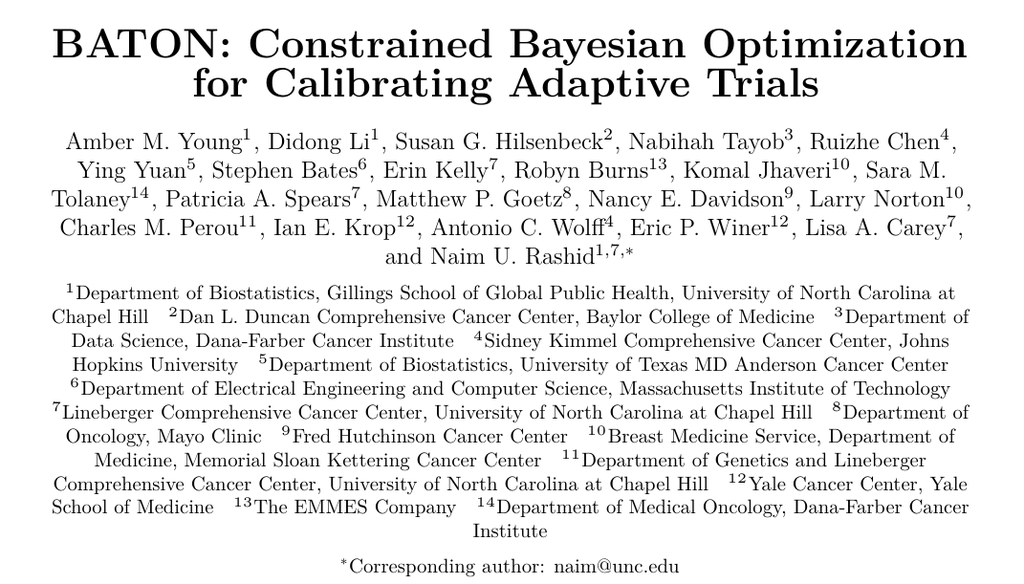

[figure not shown]

**Manuscript in revision at JASA**  
**Open-source R package**  
**Bring your own trial simulator**

github.com/rashidlab/BATON

## Acknowledgments

EVOLVE / ADAPT

MPIs

- Lisa Carey UNC
- Ian Krop Yale
- Chuck Perou UNC
- Eric Winer Yale
- Antonio Wolff Hopkins

EVOLVE steering committee and TBCRC site investigators

ARPA-H ADAPT program leadership

Statistics / BATON

- Amber Young Rashid Lab PhD student

  who led BATON's design and validation, and co-leads BATON-C
- Dinelka Nanayakkara Rashid Lab PhD student

  who leads BATON-D
- Didong Li UNC
- Rashid Lab

ARPA-H Statistics Working Group

- Susan Hilsenbeck Baylor
- Nabihah Tayob DFCI
- Ruizhe Chen Hopkins

BATON funding

ARPA-H ADAPT (ARPA-H-MAI-24-01-03, award 140D042590009) · DoD HT9425241103100121

NIH/NCI U01 CA274298, P50 CA257911, T32 CA106209, P30 CA016086, and P50 CA058223

UNC Lineberger Comprehensive Cancer Center and its University Cancer Research Fund

Thank you

Questions

On 12 problems with a known best design, BATON met both targets, 3.6% above the best on average.  
On one EVOLVE subtrial, BATON beat a grid search that used about 47 times the computing.

naim@unc.edu · rashidlab.github.io  
BATON R package: github.com/rashidlab/BATON  
Manuscript in revision

## References

1. [Biotechnology Innovation Organization, Informa Pharma Intelligence, QLS Advisors. Clinical Development Success Rates and Contributing Factors 2011–2020. 2021.](https://go.bio.org/rs/490-EHZ-999/images/ClinicalDevelopmentSuccessRates2011_2020.pdf)
2. [Wouters OJ, McKee M, Luyten J. JAMA 2020;323(9):844–853, corrected 2022.](https://doi.org/10.1001/jama.2020.1166)
3. [U.S. Department of Health and Human Services. Operation TrialBlazer roadmap. 2026.](https://www.hhs.gov/sites/default/files/operation-trialblazer.pdf)
4. [Hitchen et al. Adult solid-tumor Phase I trials with an Australian site. 2024.](https://pubmed.ncbi.nlm.nih.gov/38923830/)
5. [Getz K. Characterizing white space in the quest to drive development speed. Applied Clinical Trials, 2021.](https://www.appliedclinicaltrialsonline.com/view/characterizing-white-space-in-the-quest-to-drive-development-speed)
6. [Hwang et al. JAMA Internal Medicine 2016.](https://jamanetwork.com/journals/jamainternalmedicine/fullarticle/2565686)
7. [Hong et al. KRAS G12C inhibition with sotorasib in advanced solid tumors. NEJM 2020;383:1207–1217.](https://doi.org/10.1056/NEJMoa1917239)
8. [Sotorasib 960 mg and 240 mg randomized dose comparison. 2024.](https://pubmed.ncbi.nlm.nih.gov/39029295/)
9. [FDA Oncologic Drugs Advisory Committee briefing document, sotorasib, Table 29.](https://www.fda.gov/media/172698/download)
10. [FDA. Adaptive Designs for Clinical Trials of Drugs and Biologics. Guidance for industry, 2019.](https://www.fda.gov/media/78495/download)
11. [Simon R. Optimal two-stage designs for phase II clinical trials. Controlled Clinical Trials 1989.](https://pubmed.ncbi.nlm.nih.gov/2702835/)
12. [Jung SH, Lee T, Kim K, George SL. Admissible two-stage designs for phase II cancer clinical trials. Statistics in Medicine 2004.](https://pubmed.ncbi.nlm.nih.gov/14755389/)
13. [Rashid N. When Biomarkers, Assays, and Protocols Co-evolve. FDA CDRH OSEL seminar, 2026.](https://rashidlab.github.io/talks/2026-05-fda-cdrh-osel-coevolve-deck/when-biomarkers-assays-protocols-coevolve.html)
14. [FDA. Step 3: Clinical Research (trial sizes by phase).](https://www.fda.gov/patients/drug-development-process/step-3-clinical-research)
15. [FDA. 22 Case Studies Where Phase 2 and Phase 3 Trials Had Divergent Results. 2017.](https://www.fda.gov/about-fda/reports/22-case-studies-where-phase-2-and-phase-3-trials-had-divergent-results)
16. [Abraham et al. The PARTNER trial. Nature 2024.](https://www.nature.com/articles/s41586-024-07384-2)
17. [BATON software and manuscript (in revision).](https://github.com/rashidlab/BATON)

Backup

Reference slides

## Backup: the surrogate and the acquisition

- Gaussian process models for the **weighted loss** and each constraint.
- Proportion constraints use design-specific binomial Monte Carlo variances.
- **Expected constrained improvement** multiplies expected objective gain by modeled feasibility.
- The reported calibrations used DiceKriging GP fits.

## Backup: ten starts on one Simon benchmark

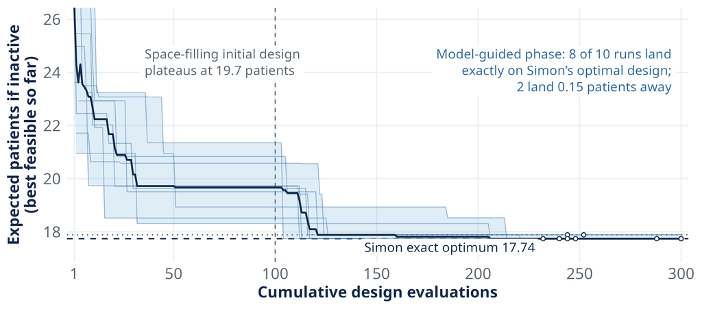

All ten runs finished within 1% of the optimum under narrower search bounds. Eight matched the known design.

## Backup: what the constraints and parameters actually are

**Calibrated (searched) parameters, single-arm:**

- maximum enrollment; interim spacing; minimum-events gate before decisions count
- posterior futility threshold; posterior efficacy threshold
- decision margin over the historical benchmark
- analysis-prior concentration; hazard-model resolution (piecewise intervals)

Seamless adds conversion and second-stage settings (13 possible, up to 11 active in the reported calibrations).

**Why the TNBC designs tie at 30**  
On backup B8, Admissible and Minimax both reach the lowest maximum enrollment searched. Minimax also requires at least eight events before an interim decision.

**Constraints (headline scenarios):**

- type I error at most the ceiling (0.10 in the scenarios shown)
- power at least the floor (0.80)
- seamless designs add gate-behavior constraints (null conversion rate bounded, alternative conversion rate floored)

**Objectives, by philosophy:** expected null enrollment (H0-Optimal), maximum enrollment (Minimax), weighted blends (Admissible family), expected alternative enrollment (H1-Optimal).

Scenario A truths: null median 3.8 months, alternative 9 (median ratio 0.42), Weibull shape 1.3, accrual 2 per month; maximum enrollment searched in [30, 120]. Two Simon scenarios use a 0.05 ceiling with 0.90 power.

## Backup: related work and what BATON adds

**Existing approaches**

- **BOP2 / GBOP2** (Zhou; Zhao): grid or particle-swarm search over posterior-probability stopping thresholds; return one design under one criterion.
- **Operating-characteristic acceleration** (Golchi 2022): speeds the estimation, does not optimize the design.
- **Single-objective BO for trial design** (Richter 2022): one objective, without multi-constraint feasibility.
- **gsDesign / rpact**: group-sequential design tools. **BATSS**: Bayesian adaptive trial simulation.

**What BATON adds, jointly in one framework**

1. finds **feasible** designs under **multiple noisy** behavior constraints;
2. carries design-specific Monte Carlo variance into the proportion constraint models;
3. optimizes under **philosophy-specific** sample-size objectives.

It returns certified designs that can be compared across enrollment objectives.

## Backup: known failure modes and limits

- **Budget exhaustion**: 3 of 10 reproducibility runs used the full 300-evaluation budget rather than stopping early; quote evaluations used, not “convergence.”
- **Approximate optimization**: worst single-run benchmark gap was 13.5%. For certified designs, the constraint statements have 95% familywise confidence within each certification family at the simulated scenarios.
- **Correlated constraints**: the acquisition multiplies marginal feasibility probabilities; latent surfaces for power and type I error can be correlated. Affects the search only; reported designs are verified directly.
- **No common random numbers in the loop**: candidate comparisons carry full independent Monte Carlo noise; verification uses a shared seed set.
- **One assumed truth per calibration**: every current result conditions on an assumed clinical scenario; robustness across scenarios is BATON-C, in progress.

## Backup: bidirectional stopping variants

The single-arm and between-arm headline scenarios use futility-only interim stopping (interims can stop for futility; efficacy is decided at the end). The seamless design is calibrated with bidirectional stopping throughout, because its conversion gate is efficacy-driven.

- The choice between stopping structures is itself a design decision upstream of the philosophy choice.

## Backup: ten seeds, one design

The whole pipeline, rerun end to end at ten independent random seeds:

| Runs returning a feasible design | **10 / 10** |
| --- | --- |
| Runs within 1% of Simon’s optimum | **10 / 10** |
| Runs returning Simon’s exact optimal design | **8 / 10** |
| Expected null enrollment, mean (spread) | **17.77** (0.06) |
| Evaluations used, median | 250 of a 300 budget |

The other two seeds return a near-neighbor design (max sample size 29 instead of 25) whose expected enrollment differs by 0.15 patients. What reproduces is the design’s behavior, and usually the design itself.

Rerunning the search shows how much the returned design and its behavior change with the seed.

## Backup: the TNBC single-arm frontier

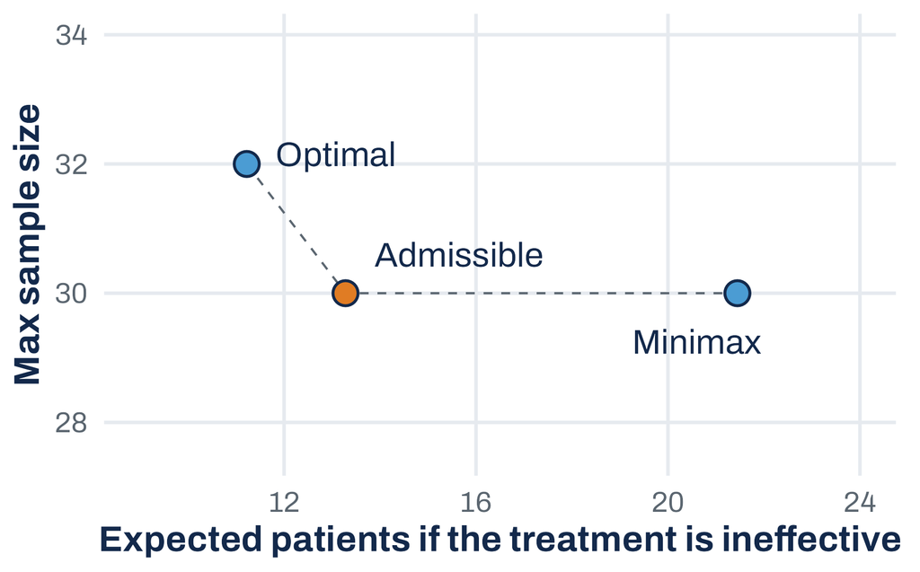

TNBC single-arm subtrial. Optimal: 32 max, 11.2 expected. Admissible: 30 and 13.3. Minimax: 30 and 21.4.

## Backup: the ARPA-H ask and the N-of-1 addition

*(ii) Clinical trial characteristics:*

1. Clinical trial for metastatic cancer patients.
2. Clinical trial that includes multiple lines of therapy under a single protocol.
3. Flexible clinical trial protocol that enables changes in design (e.g., randomized, adaptive, etc.).
4. Strong capability to collect tumor and blood-based measurements.
5. Possess a treatment line with a Progression Free Survival (PFS) rate of <9 months average.
6. Mechanisms for biomarker evaluation.
7. Modular clinical trial design enabling rapid dissemination and protocol uptake by different sites.

*(iii) General characteristics:* key clinical needs; evolutionary design examples and rapid-enrollment plans; treatment lines; biomarker testing and integration plans.

excerpts from the ARPA-H solicitation and program-manager correspondence

**Follow up** (program-manager email): integrate an "N-of-1" trial component.

The ask: design an adaptive multi-line trial to discover, evaluate, and implement novel biomarkers, with an additional N-of-1 subcomponent

[figure not shown]

## Backup: ADAPT technical areas and the EVOLVE team

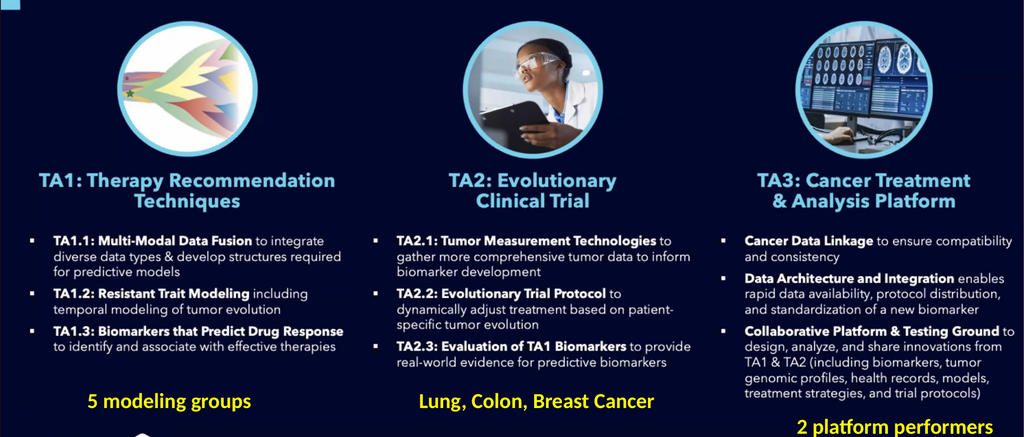

[figure not shown]

## Backup: Across 12 benchmarks: feasible in all 12, mean objective gap 3.6%

One run per scenario; ratio = BATON’s expected null enrollment / Simon’s exact optimum.

| Claim | Value |
| --- | --- |
| Feasible design returned | 12 / 12 |
| Exact Simon design returned | 4 / 12 |
| Mean ratio, BATON / Simon (SD) | 1.036 (0.041) |
| Worst-case ratio | 1.135 |
| Best-case ratio | 1.000 |

Feasibility is verified directly. Objective optimization remains approximate.

## Backup: The seed sketches the map. Then BATON proposes each batch.

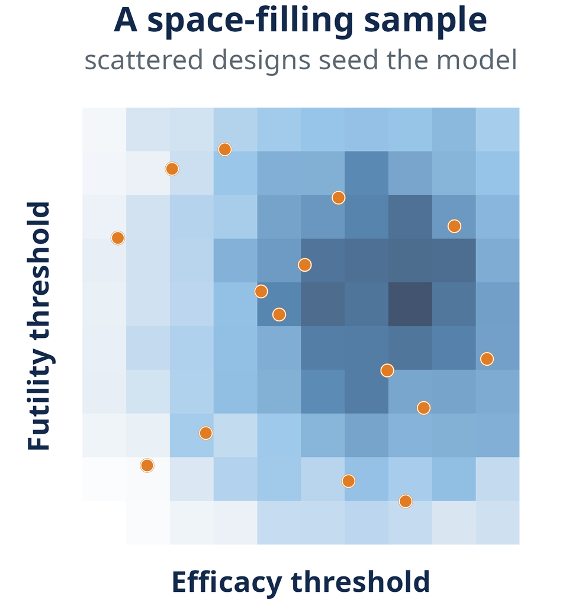

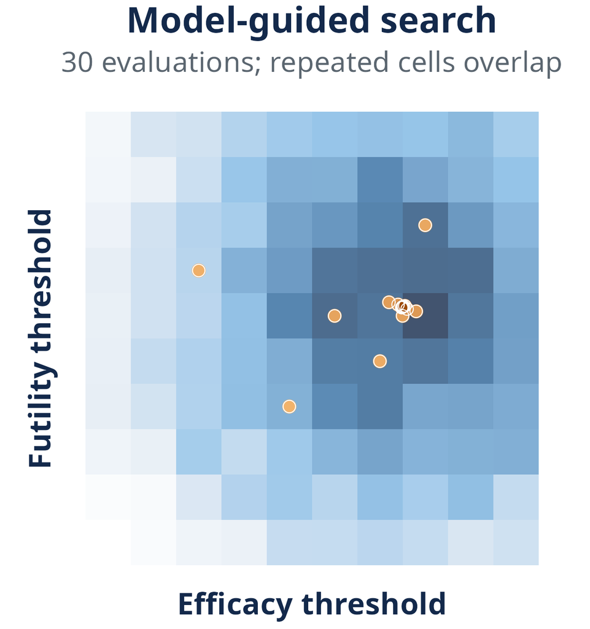

Initial points learn broadly; later points concentrate where the answer may improve.

## Backup: Calibrating a seamless design

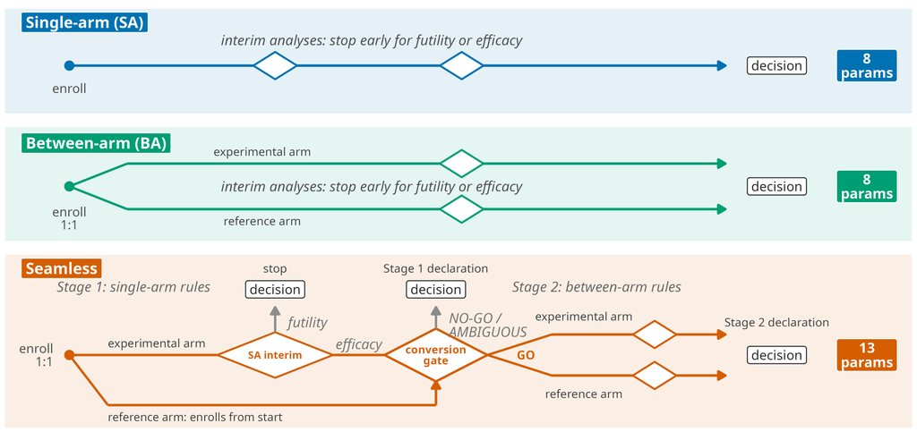

**Stage 1**Randomize from the start. Screen the experimental arm against the historical benchmark, then apply the conversion rule. **Stage 2**For trials that continue, compare the randomized arms. The reported calibrations stopped at the first Stage 2 look.

The seamless design had 13 possible settings. At most 11 were active in the reported calibrations.

## Backup: the U.S. is concerned about its lead in early clinical research

**U.S. Department of Health and Human Services**

HHS reports that China’s global share of Phase I trials first exceeded the U.S. share in 2021.

[Operation TrialBlazer roadmap, 2026](https://www.hhs.gov/sites/default/files/operation-trialblazer.pdf)

Australia · adult solid-tumor Phase I trials

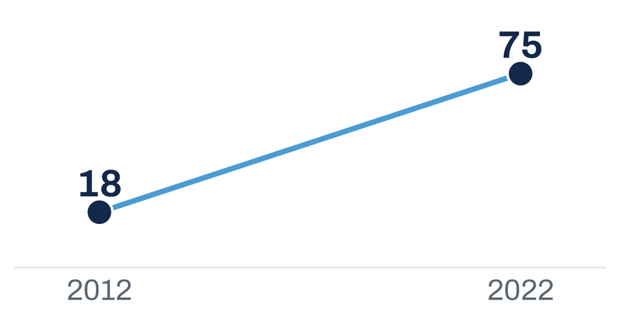

Adult solid-tumor Phase I trials with an Australian site. [Hitchen et al., 2024](https://pubmed.ncbi.nlm.nih.gov/38923830/)